# Презентация по разделу №2 ‘Защита ПК/телефона’ внешнего курса на тему ‘Основы кибербезопасности’

Основы информационной безопасности

Татьяна Александровна Пономарева

Российский университет дружбы народов

2026-04-29

# Информация

## Докладчик

*Пономарева Татьяна Александровна* Студент группы НКАбд-04-24 *Российский университет дружбы народов им. П. Лумумбы* taponomareva6742@gmail.com *https://github.com/taponomareva

# Вводная часть

## Цель работы

Выполнить задания раздела 2 и понять, что входит в защиту ПК/телефона.

## Теоретическое введение

Данный курс рассчитан на любого пользователя ПК/смартфона/банкомата и состоит из 3-х разделов, также он содержит лекции, материалы для доп. чтения и тесты [1].

# Выполнение заданий раздела 2 “Защита ПК/телефона”

## Шифрование диска. Зашифровка загрузочного сектора диска

Загрузочный сектор диска можно зашифровать (рис. 1).

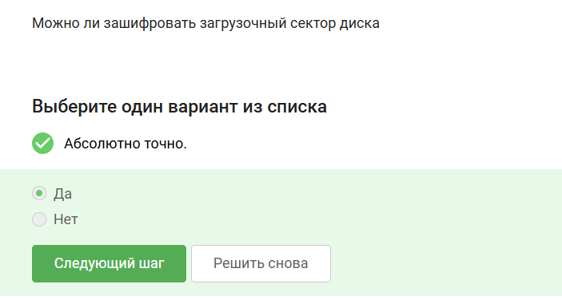

Рисунок 1: Зашифровка загрузочного сектора диска

## Основа шифрования диска

Шифрование диска основано на симметричном шифровании (рис. 2).

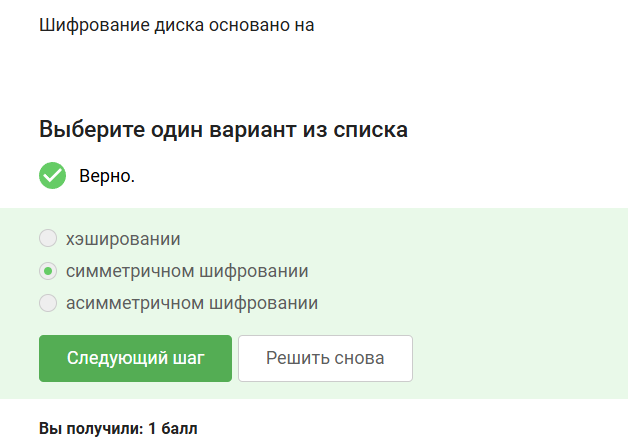

Рисунок 2: Основа шифрования диска

## Программы для шифрования диска

С помощью BitLocker и VeraCrypt можно зашифровать жесткий диск (рис. 3).

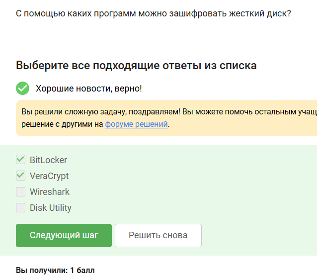

Рисунок 3: Программы для шифрования диска

## Пароли. Стойкий пароль

К стойкому паролю можно отнести UQr9@j4!S$ (рис. 4).

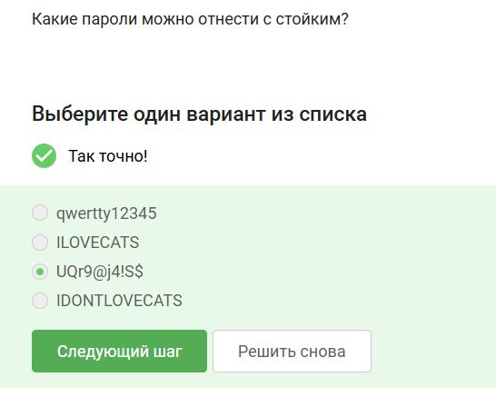

Рисунок 4: Стойкий пароль

## Хранение паролей

Пароли безопасно хранить в менеджерах паролей (рис. 5).

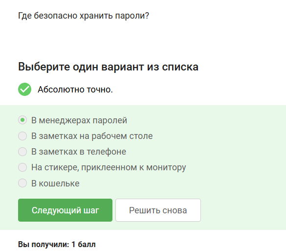

Рисунок 5: Хранение паролей

## Функция капчи

Капча нужна для защиты от автоматизированных атак, направленных на получение несанкционированного доступа (рис. 6).

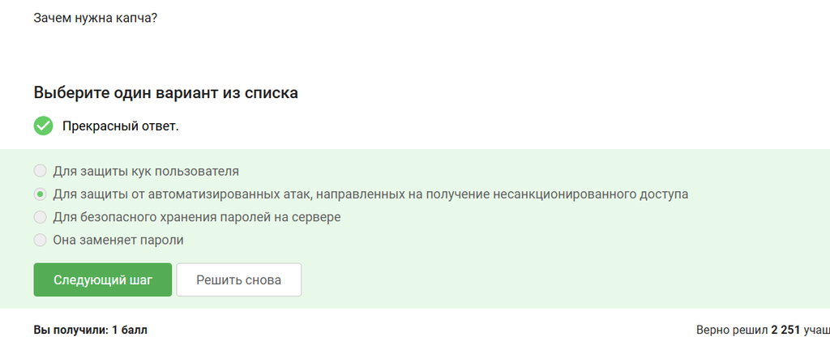

Рисунок 6: Функция капчи

## Функция хэширования паролей

Хэширование паролей применяется для того, чтобы не хранить пароли на сервере в открытом виде (рис. 7).

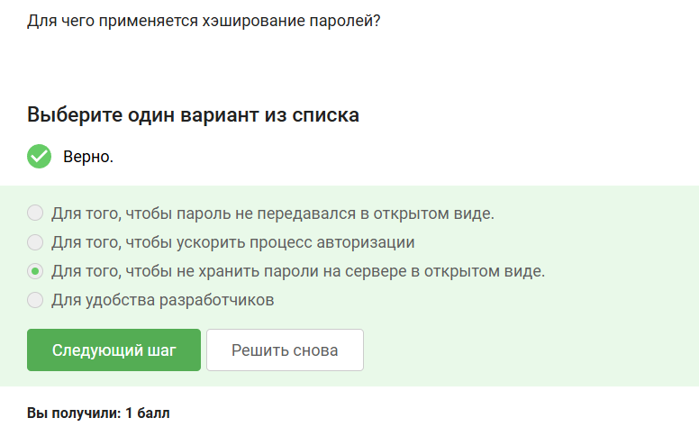

Рисунок 7: Функция хэширования паролей

## Соль для улучшения стойкости паролей и злоумышленник

Если злоумышленник получил доступ к серверу, то соль для улучшения стойкости паролей к атаке перебором не поможет (рис. 8).

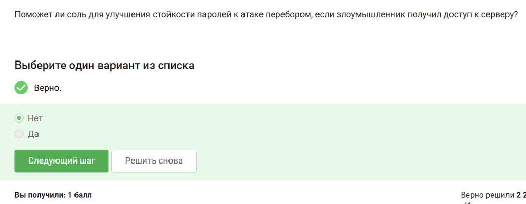

Рисунок 8: Соль для улучшения стойкости паролей и злоумышленник

## Меры защиты от утечек данных

Меры защиты от утечек данных атакой перебором: разные пароли на всех сайтах, периодическая смена паролей, сложные(=длинные) пароли, капча (рис. 9).

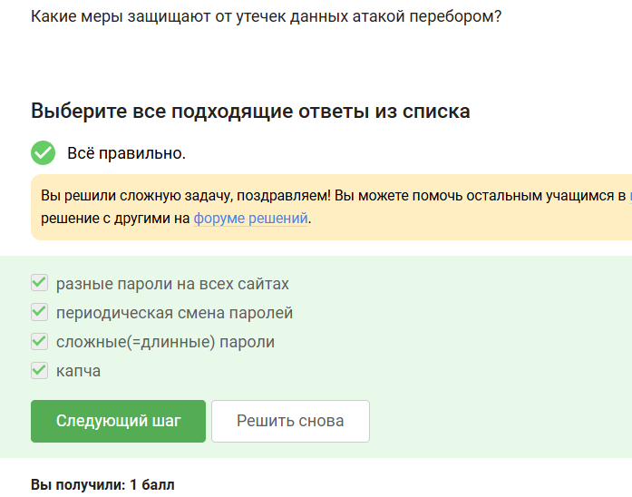

Рисунок 9: Меры защиты от утечек данных

## Фишинг. Фишинговые ссылки

Следующие ссылки являются фишинговыми, т к они маскируются под существующие сервисы и обманывают пользователей, забирая их данные (рис. 10).

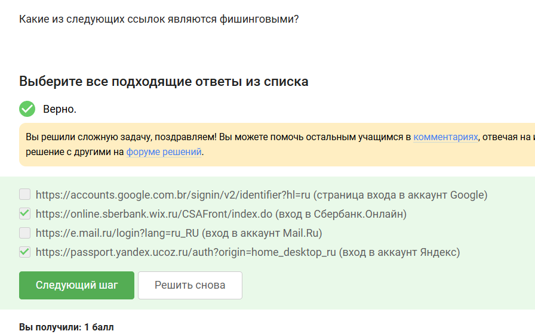

Рисунок 10: Фишинговые ссылки

## Фишинговые ссылки от знакомого адреса

Фишинговый имейл может прийти от знакомого адреса (рис. 11).

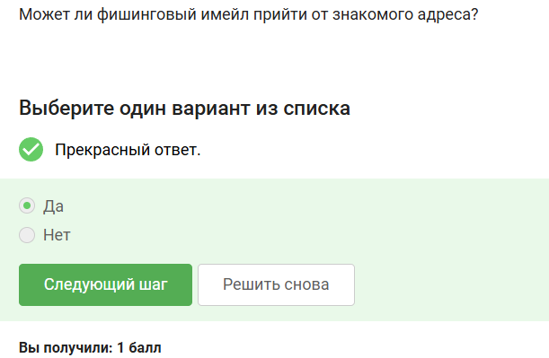

Рисунок 11: Фишинговые ссылки от знакомого адреса

## Вирусы. Примеры. Email Спуфинг

Email Спуфинг - это подмена адреса отправителя в имейлах (рис. 12).

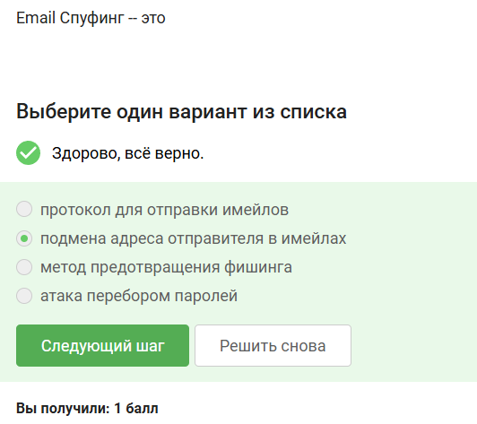

Рисунок 12: Email Спуфинг

## Вирус-троян

Вирус-троян маскируется под легитимную программу (рис. 13).

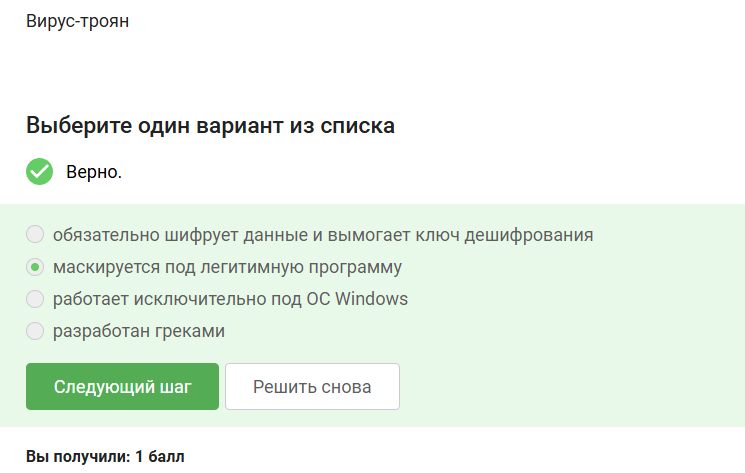

Рисунок 13: Вирус-троян

## Безопасность мессенджеров. Ключ шифрования в протоколе мессенджеров Signal

Ключ шифрования в протоколе мессенджеров Signal формируется при генерации первого сообщения стороной-отправителем (рис. 14).

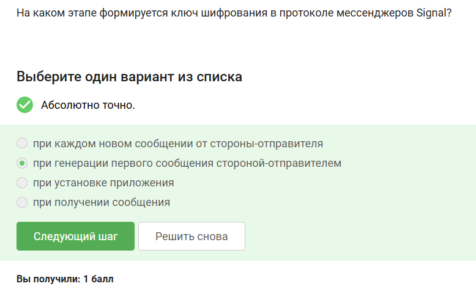

Рисунок 14: Ключ шифрования в протоколе мессенджеров Signal

## Суть сквозного шифрования

Суть сквозного шифрования состоит в том, что сообщения передаются по узлам связи (серверам) в зашифрованном виде (рис. 15).

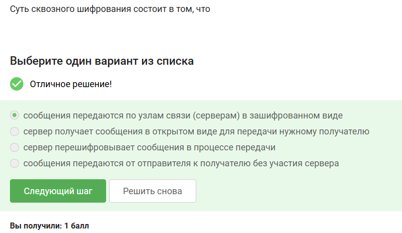

Рисунок 15: Суть сквозного шифрования

# Выводы

В ходе прохождения раздела 2 внешнего курса были выполнены задания раздела 2 и была изучена характеристика защиты ПК/телефона.

# Список литературы

1. И. Канта Б. им. Основы кибербезопасности: Внешний курс на платформе Stepik [Электронный ресурс]. Платформа Stepik. URL: https://stepik.org/111512 (дата обращения: 29.04.2026).